# Kidney transplantation vs dialysis among elderly people:Markov based analysis

# **09 Cost-effectiveness Ratio (CER)**

```r
## Incremental cost-effectiveness ratios (ICERs)
# using the dampack package
df_cea <- calculate_icers(cost       = v_tot_cost,
                          effect     = v_tot_qaly,
                          strategies = v_names_str)
df_cea
```

```
##                              Strategy     Cost   Effect Inc_Cost Inc_Effect
## ECD/DCD transplant ECD/DCD transplant 434219.0 5.703778       NA         NA
## Continued dialysis Continued dialysis 694883.3 4.604556       NA         NA
##                    ICER Status
## ECD/DCD transplant   NA     ND
## Continued dialysis   NA      D
```

```r
# Transplant costs less and gives more QALYs, so continued dialysis is dominated ("D") and no ICER is calculated.
```

```r
## CEA table in proper format
# using the dampack package
table_cea <- format_table_cea(df_cea)
table_cea
```

```
##                              Strategy Costs ($) QALYs Incremental Costs ($)
## ECD/DCD transplant ECD/DCD transplant   434,219   5.7                  <NA>
## Continued dialysis Continued dialysis   694,883   4.6                  <NA>
##                    Incremental QALYs ICER ($/QALY) Status
## ECD/DCD transplant                NA          <NA>     ND
## Continued dialysis                NA          <NA>      D
```

```r
## (not in template) Incremental results vs continued dialysis
wtp <- 50000   # willingness-to-pay threshold, $ per QALY
df_incr <- data.frame(Strategy    = v_names_str,
                      Cost        = round(v_tot_cost),
                      QALYs       = round(v_tot_qaly, 3),
                      Inc_Cost    = round(v_tot_cost - v_tot_cost[1]),
                      Inc_QALYs   = round(v_tot_qaly - v_tot_qaly[1], 3),
                      Inc_NMB     = round(wtp * (v_tot_qaly - v_tot_qaly[1]) - (v_tot_cost - v_tot_cost[1])))
df_incr
```

```
##                              Strategy   Cost QALYs Inc_Cost Inc_QALYs Inc_NMB
## Continued dialysis Continued dialysis 694883 4.605        0     0.000       0
## ECD/DCD transplant ECD/DCD transplant 434219 5.704  -260664     1.099  315625
```

```r
# expected incremental cost about -260,664; incremental QALYs about +1.099;
# incremental net monetary benefit at $50,000/QALY about 315,625
```

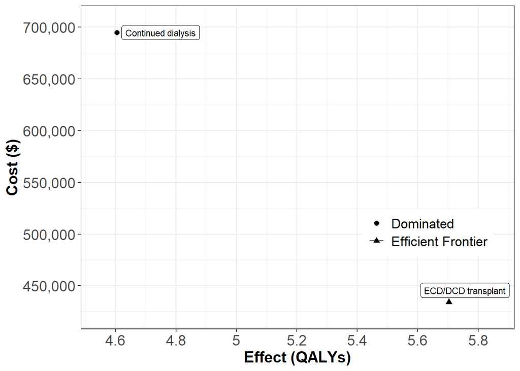

```r
## CEA frontier
# using the dampack package
plot_icers(df_cea, label = "all", txtsize = 16) +
  expand_limits(x = max(table_cea$QALYs) + 0.1) +
  theme(legend.position = c(0.8, 0.3))
```

# **10 Deterministic Sensitivity Analysis (DSA)**

```r
## Load model, CEA and PSA functions
source('Functions_SA_Tunnels.R')
results_dir <- file.path('results', 'tunnels_ageing')   # >>> CHANGED (ageing): new folder, so the no-ageing results are kept
dir.create(results_dir, recursive=TRUE, showWarnings=FALSE)
```

## 10.1 Model input for SA

```r
# A function was added to Functions_SA_Tunnels.R to be called in this analysis.
l_params_all <- get_base_params()

#l_params_all
```

**Helper Functions in Functions_SA_Tunnels.R**

> > > main functions in `Functions_SA_Tunnels.R` are:
- `get_base_params()`: base-case inputs. The constant death rates `r_dial_dead` and `r_G_dead` are replaced by the extra death rates `r_dial_exc` and `r_G_exc` (added to the population rate at each age), and the life table (`v_q_pop`, ages 75–109) and `age_start` are added.
- `run_model_traces()`: builds the age-dependent probabilities, the 3-D transition arrays and the cohort traces for both strategies (same steps as sections 03.1, 04.3 and 05).
- `calculate_ce_out()`: calls `run_model_traces()` and computes total costs, QALYs and net monetary benefit (NMB) for each strategy, with Simpson’s 1/3 correction and the same discounting as section 08.
- `calibrate_base_params()`: recalculates `r_dial_exc` and `r_G_exc` from the life table and the 5-year targets (55% and 59%).
- `generate_psa_params()`, `get_sa_spec()`, `get_owsa_ranges()`: unchanged.

```r
# 1. Life table: values stored in get_base_params() is same for values read from the CSV (section 03.1, Step 0)
stopifnot(isTRUE(all.equal(l_params_all$v_q_pop, v_q_pop)))

# 2. Calibration: same extra death rates as section 03.1 (Steps 1 and 6)
v_calib <- calibrate_base_params()
v_calib                                  # r_dial_exc about 0.0892, r_G_exc about 0.0419
```

```
## r_dial_exc    r_G_exc
## 0.08923827 0.04194424
```

```r
stopifnot(isTRUE(all.equal(unname(v_calib["r_dial_exc"]), r_dial_exc,           tolerance = 1e-6)),
          isTRUE(all.equal(unname(v_calib["r_G_exc"]),    r_G_exc,              tolerance = 1e-6)),
          isTRUE(all.equal(l_params_all$r_G_exc,          r_G_exc,              tolerance = 1e-6)))
```

```r
# Try the calculate_ce_out() function
df_ce <- calculate_ce_out(l_params_all)
df_ce
# expected costs about 694,883 and 434,219; QALYs about 4.605 and 5.704

# >>> NEW (ageing) 3. Base case: same totals as section 08 (v_tot_cost, v_tot_qaly)
stopifnot(isTRUE(all.equal(df_ce$Cost,   as.numeric(v_tot_cost), tolerance = 1e-6)),
          isTRUE(all.equal(df_ce$Effect, as.numeric(v_tot_qaly), tolerance = 1e-6)))

# Get strategies names (will be used to label plots)
v_names_str <- df_ce$Strategy
n_str <- length(v_names_str)
```

## 10.2 One-way sensitivity analysis (OWSA)

The OWSA ranges come from the literature (published 95% CIs, other cohorts of older recipients, other Canadian dialysis modalities, CADTH guidance). Same values are used for the PSA SEs (section 11) and used 10% of the mean otherwise(this came from the literature(Franklin & Hunter (2019) AND Brodtkorb et al. (2024))

Two death rates are calibrated, so their ranges are found by re-calibrating to the ends of the published CI for 5-year survival

```r
## Literature-based ranges for the OWSA
k_cpi_2019 <- 164.2 / 136.0          # CPI 2019 -> 2025 (Statistics Canada [7]; 2019 = 136.0)
# Base-case dialysis cost without the facility HD component (2016 CAD per month), see section 03 "c_dial"
c_dial_other_2016 <- c_dial / k_cpi - 50075.81 / 12
# Relative width of the 95% CI of the 2-year deceased-donor transplant cost [6]:
# $121,121 (95% CI 114,287 to 127,956)
v_tx_ci_rel <- c(114287, 127956) / 121121          # 0.944 and 1.056

df_owsa_lit <- data.frame(
  pars = c("r_dial_exc", "r_G_exc", "hr_early", "r_GL_y1", "r_GL_y2p",
           "p_GL_dead_annual", "u_dial", "u_graft",
           "c_dial", "c_G1to3", "c_G4to12", "c_G13p", "c_tx_once",
           "d_c", "d_e", "early_utility_fraction", "n_cycles"),
  min  = c(r_dial_exc,                                                  # 55% alive at 5 y (base) [1]
           calibrate_base_params(surv5_tx = 0.66)["r_G_exc"],           # 66% at 5 y (upper 95% CI) [1]
           1.50,                                                        # lower 95% CI of HR 2.29 [2]
           -log(0.955),                                                 # 95.5% 1-y DCGS, older DCD kidneys [14]
           -log(0.860 / 0.902) / 4,                                     # 90.2% at 1 y, 86.0% at 5 y, donors and recipients >=65 [17]
           0.474,                                                       # lower 95% CI [4]
           0.82 - 0.15,                                                 # transplant 0.82 minus upper CI of decrement 0.15 [8]
           0.74,                                                        # lower 95% CI, TTO referent [8]
           k_cpi * (c_dial_other_2016 + 29969.07 / 12),                 # home PD (CAPD) instead of facility HD [5]
           c_G1to3  * v_tx_ci_rel[1],                                   # [6]
           c_G4to12 * v_tx_ci_rel[1],
           c_G13p   * v_tx_ci_rel[1],
           c_tx_once * v_tx_ci_rel[1],
           0, 0,                                                        # CADTH: 0% [9]
           0,                                                           # dialysis utility in months 1-3 (base)
           60),                                                         # 5-year horizon
  max  = c(calibrate_base_params(surv5_dial = 0.54)["r_dial_exc"],      # 54% at 5 y (lower 95% CI) [1]
           calibrate_base_params(surv5_tx = 0.51)["r_G_exc"],           # 51% at 5 y (lower 95% CI) [1]
           3.49,                                                        # upper 95% CI of HR 2.29 [2]
           -log(0.902),                                                 # 90.2% 1-y DCGS, donors and recipients >=65 [17]
           r_GL_y2p,                                                    # base (DCD [13]) is the highest published estimate
           0.533,                                                       # upper 95% CI [4]
           0.82 - 0.08,                                                 # transplant 0.82 minus lower CI of decrement 0.08 [8]
           0.90,                                                        # upper 95% CI, TTO referent [8]
           k_cpi_2019 * 67415.55 / 12 +                                 # in-centre HD, Manitoba 2019 [18],
             k_cpi * (c_dial_other_2016 - (6614 + 5475) / 12),          #   replacing facility HD + physician + capital
           c_G1to3  * v_tx_ci_rel[2],
           c_G4to12 * v_tx_ci_rel[2],
           c_G13p   * v_tx_ci_rel[2],
           c_tx_once * v_tx_ci_rel[2],
           0.03, 0.03,                                                  # CADTH: 3% [9]
           1,                                                           # full graft utility from month 1 (assumption)
           n_cycles),                                                   # lifetime (base)
  source = c("Hellemans [1]: 5-y dialysis survival 55% (54-55%)",
             "Hellemans [1]: 5-y ECD/DCD survival 59% (51-66%)",
             "Leeaphorn [2]: HR 2.29 (1.50-3.49), days 0-90",
             "GEODAS [14] 95.5%; de Boer [17] 90.2%",
             "de Boer [17] 86.0% at 5 y; base Perez-Saez [13]",
             "Vanhove [4]: 50.2% (47.4-53.3%)",
             "Wyld [8]: dialysis 0.11 lower (0.08-0.15)",
             "Wyld [8]: transplant 0.82 (0.74-0.90)",
             "Ferguson [5] CAPD; Bamforth [18] in-centre HD",
             "Barnieh [6]: 95% CI of 2-y cost", "Barnieh [6]", "Barnieh [6]", "Barnieh [6]",
             "CADTH [9]", "CADTH [9]", "Assumption (scenario)", "Scenario: 5-y horizon"))
df_owsa_lit$min <- as.numeric(df_owsa_lit$min)
df_owsa_lit$max <- as.numeric(df_owsa_lit$max)
df_owsa_lit$base <- unlist(l_params_all[df_owsa_lit$pars])

# >>> NEW: the CI limits used for the PSA standard errors (get_ci_se() in the
# functions file) must be the same as the OWSA limits above
df_ci_se <- get_ci_se(l_params_all)
v_ci <- df_ci_se$pars[!is.na(df_ci_se$lower)]
stopifnot(isTRUE(all.equal(df_ci_se$lower[match(v_ci, df_ci_se$pars)], df_owsa_lit$min[match(v_ci, df_owsa_lit$pars)], tolerance = 1e-6)),
          isTRUE(all.equal(df_ci_se$upper[match(v_ci, df_ci_se$pars)], df_owsa_lit$max[match(v_ci, df_owsa_lit$pars)], tolerance = 1e-6)))
knitr::kable(df_owsa_lit[, c("pars", "base", "min", "max", "source")], digits = 4,
             caption = "One-way sensitivity analysis ranges and sources")
```

One-way sensitivity analysis ranges and sources

| pars | base | min | max | source |
| --- | --- | --- | --- | --- |
| r_dial_exc | 0.0892 | 0.0892 | 0.0929 | Hellemans [1]: 5-y dialysis survival 55% (54-55%) |
| r_G_exc | 0.0419 | 0.0169 | 0.0748 | Hellemans [1]: 5-y ECD/DCD survival 59% (51-66%) |
| hr_early | 3.0000 | 1.5000 | 3.4900 | Leeaphorn [2]: HR 2.29 (1.50-3.49), days 0-90 |
| r_GL_y1 | 0.0694 | 0.0460 | 0.1031 | GEODAS [14] 95.5%; de Boer [17] 90.2% |
| r_GL_y2p | 0.0373 | 0.0119 | 0.0373 | de Boer [17] 86.0% at 5 y; base Perez-Saez [13] |
| p_GL_dead_annual | 0.5020 | 0.4740 | 0.5330 | Vanhove [4]: 50.2% (47.4-53.3%) |
| u_dial | 0.7100 | 0.6700 | 0.7400 | Wyld [8]: dialysis 0.11 lower (0.08-0.15) |
| u_graft | 0.8200 | 0.7400 | 0.9000 | Wyld [8]: transplant 0.82 (0.74-0.90) |
| c_dial | 8928.9700 | 6786.2310 | 9087.0494 | Ferguson [5] CAPD; Bamforth [18] in-centre HD |
| c_G1to3 | 14133.1800 | 13335.7435 | 14930.7305 | Barnieh [6]: 95% CI of 2-y cost |
| c_G4to12 | 4747.6000 | 4479.7278 | 5015.5140 | Barnieh [6] |
| c_G13p | 3272.0100 | 3087.3971 | 3456.6572 | Barnieh [6] |
| c_tx_once | 61041.8000 | 57597.6474 | 64486.4645 | Barnieh [6] |
| d_c | 0.0150 | 0.0000 | 0.0300 | CADTH [9] |
| d_e | 0.0150 | 0.0000 | 0.0300 | CADTH [9] |
| early_utility_fraction | 0.0000 | 0.0000 | 1.0000 | Assumption (scenario) |
| n_cycles | 420.0000 | 60.0000 | 420.0000 | Scenario: 5-y horizon |

```r
options(scipen = 999) # disabling scientific notation in R

# make sure the base case is never a hair outside its own range (floating-point)
df_owsa_lit$min <- pmin(df_owsa_lit$min, df_owsa_lit$base)
df_owsa_lit$max <- pmax(df_owsa_lit$max, df_owsa_lit$base)

# dataframe with the parameters and their min and max values (from the literature, above)
df_params_owsa <- df_owsa_lit[, c("pars", "min", "max")]

invisible(capture.output(
  owsa_nmb <- run_owsa_det(
    params_range    = df_params_owsa,
    params_basecase = l_params_all,
    nsamp           = 100,
    FUN             = calculate_ce_out,
    outcomes        = c("NMB"),
    strategies      = v_names_str,
    n_wtp           = 50000
  )
))
```

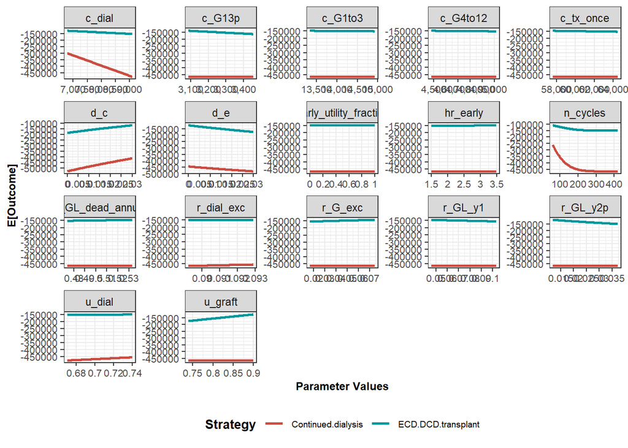

```r
plot(owsa_nmb, txtsize = 10, n_x_ticks = 4,
     facet_scales = "free") +
     theme(legend.position = "bottom")
```